# Analyses for predators of Haida Gwaii Pacific Herring

Andrew Edwards

This vignette shows how to extract and analyse the data for predators of Haida Gwaii Pacific Herring, including lumping species together (e.g. `skates_combined`). This information is for a DFO Ecosystem Approach to Fisheries Management Case Study on ecoystem influences of Haida Gwaii Pacific Herring.

The area of interest is the same as shown in the Restricted area vignette, and the shapefile is saved in the package as `HG_herring_pred_area`.

```r
library(gfiphc)
path_data = "HG-herring-predators-data"        # folder to save extracted raw data
path_results = "HG-herring-predators-results"  # folder to save results
```

## Data for species of interest

These are the species (herring predators, excluding skate species) identified by Jennifer Boldt:

```r
sp_vec <- c("yelloweye rockfish",
            "arrowtooth flounder",
            "lingcod",
            "north pacific spiny dogfish",
            "pacific cod",
            "pacific halibut",
            "redbanded rockfish",
            "sablefish",
            "walleye pollock")
```

We want a general rockfish category and general skates one. I just picked yelloweye and redbanded for rockfish for now.

## Skate species

Unidentified (species of) skates were enumerated in the early years, but then declined dramatically and had zero counts in 2001, 2002 and 2013, and presumably for 2003 onwards (but those data are in GFbio which would have to be checked – seems clear that the identification protocol improved through time). So after investigating this (in earlier versions of this vignette), am now including unidentified skate in the species list.

Looking through 2019 synopsis report and the plots below (and a look at the data up to 2020; not doing again for 2022), here are the decisions on including each skate species:

```r
skate_sp <- c("aleutian skate",
              "big skate",
              "roughtail skate",
              "sandpaper skate",
              "longnose skate",
              "alaska skate",
              "unidentified skate")

skate_ignore <- c("abyssal skate",
                  "broad skate")
```

Cache the data if needed:

```r
cached_data = TRUE     # whether or not to use already-saved data, set FALSE
                       #  for first run each year then TRUE
if(!cached_data){
  cache_pbs_data_iphc(sp_vec,
                      path = path_data)
  cache_pbs_data_iphc(skate_sp,
                      path = path_data)
  cache_pbs_data_iphc(skate_ignore,
                      path = path_data)
}
```

## Individual skate species

Calculate series for each skate species in turn (saved as `species_name_area`) and plot figures of Series E and F and longest from those. The fourth panel has Series EF which is the longest time series possible; if it is blank then Series E or F are the longest (and automatically identified). But this only happens for the rare species, and so not when the skate species are combined.

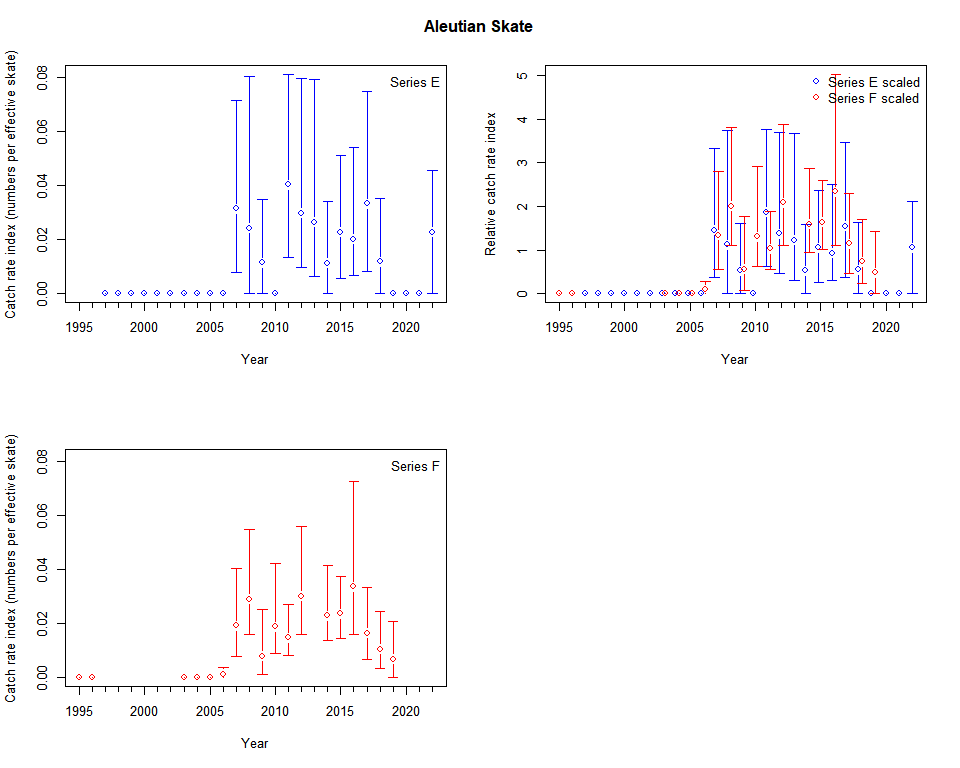

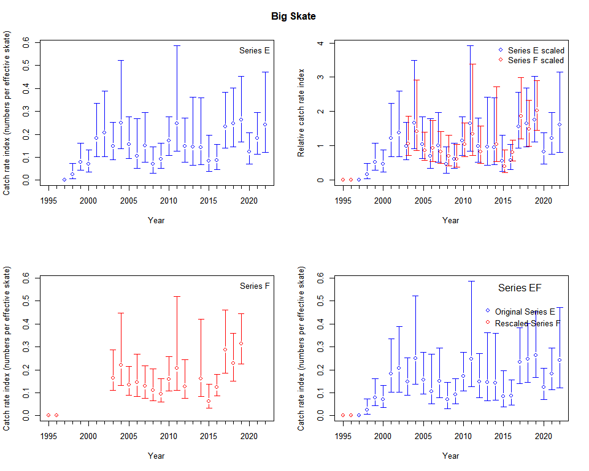

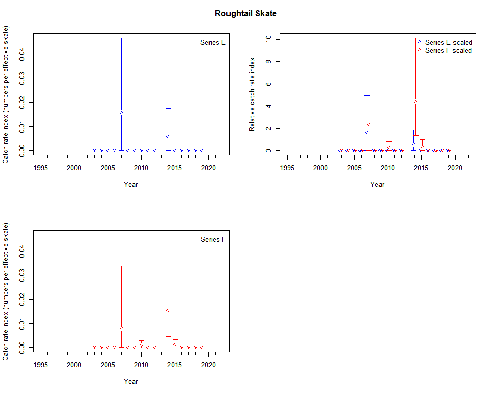

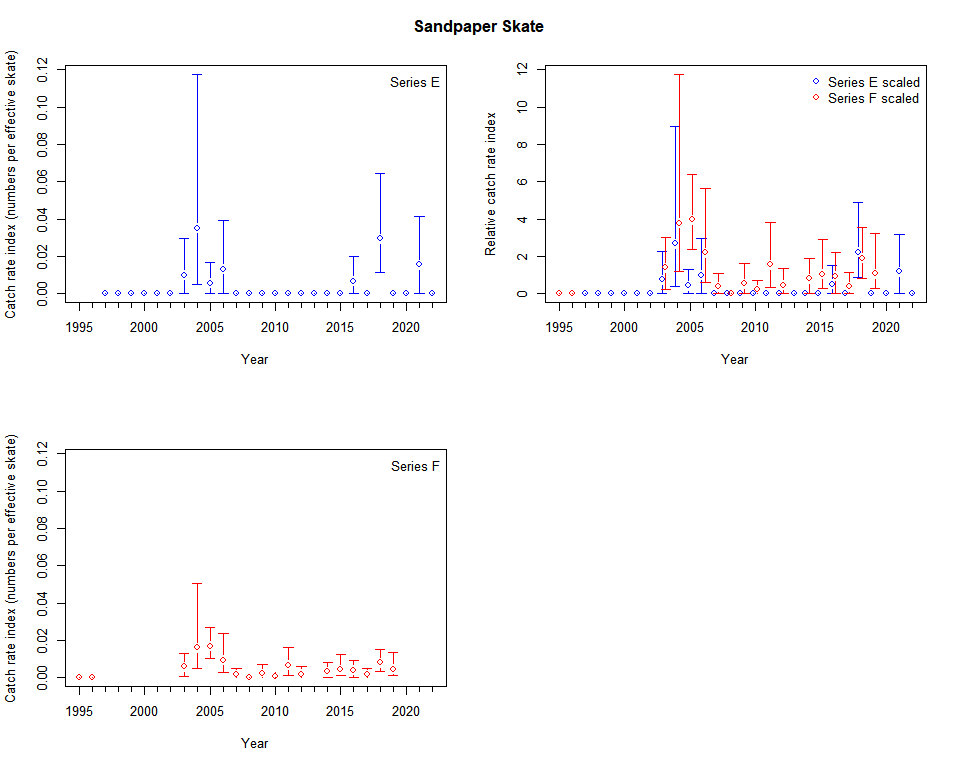

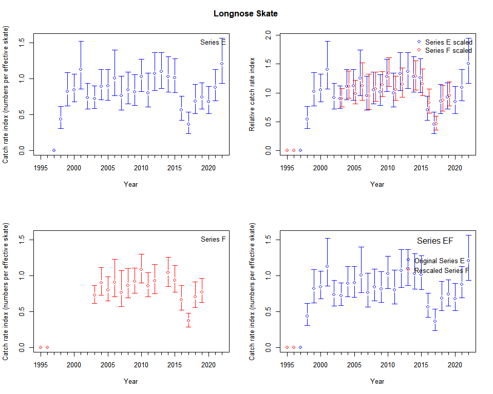

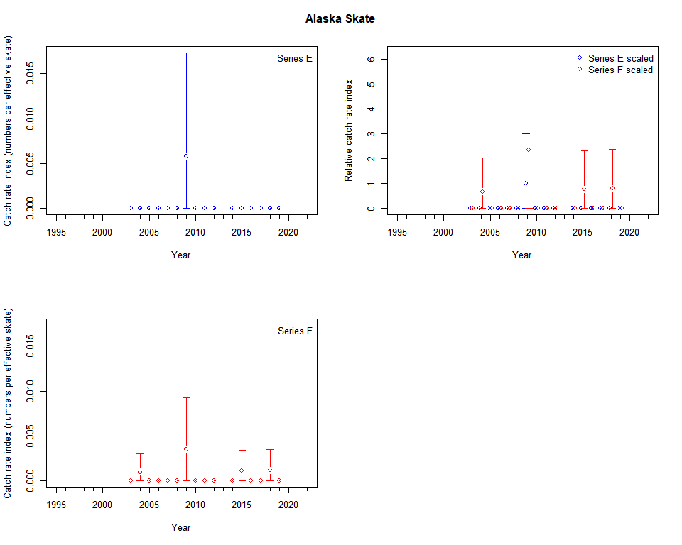

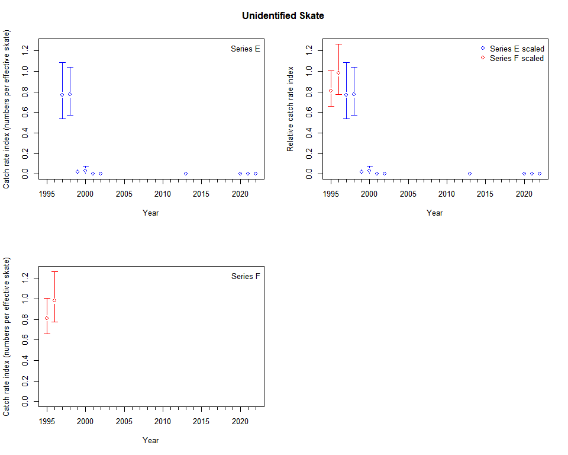

```r
cached_results = TRUE   # whether or not to use already-saved results (FALSE for
                        # first run)
for(sp in skate_sp){
  assign(sp_hyphenate(sp,
                      underscore = TRUE,
                      area = TRUE),
         iphc_get_calc_plot_area(sp,
                                 cached_data = cached_data,
                                 cached_results = cached_results,
                                 path_data = path_data,
                                 path_results = path_results))
}
```

## Unidentified skate

Above figure shows that for 1995 and 1996 there are ‘Unident. skate’, and then for a few years after that (but at lower numbers). Can see from species figures above that indeed no skate species were identified for those years. And it looks like then big and longnose were identified but not others for a few years.

First looking into the raw data:

```r
# 1995
unique(countData1995$spNameIPHC)[grep("Skate", unique(countData1995$spNameIPHC))]
```

```
#> [1] "unident. Skate" "Skate Egg Case"
```

```r
grep("skate", unique(countData1995$spNameIPHC)) # none
```

```
#> integer(0)
```

```r
# And a manual check through confirms, that all we need is "unident. Skate"

#1996 to 2002 has "unident. Skate", but only up to 2000:
unique(data1996to2002$spNameIPHC)[grep("Skate",
                                       unique(data1996to2002$spNameIPHC))]
```

```
#> [1] "unident. Skate" "Longnose Skate" "Big Skate"      "Starry Skate"
#> [5] "Black Skate"
```

```r
grep("skate", unique(data1996to2002$spNameIPHC)) # none
```

```
#> integer(0)
```

```r
dplyr::filter(data1996to2002,
              spNameIPHC == "unident. Skate") %>%
  tail()
```

```
#> # A tibble: 6 × 13
#>    year station   set   lon   lat depth…¹ spCod…² spNam…³ catch…⁴ skates hooks…⁵
#>   <dbl>   <dbl> <dbl> <dbl> <dbl>   <dbl>   <dbl> <chr>     <dbl>  <dbl>   <dbl>
#> 1  1999    2144    36 -133.  53.3     146      55 uniden…       1      8     160
#> 2  1999    2159    31 -131.  54.3      38      55 uniden…       1      8     160
#> 3  2000    2065    95 -128.  51.5      47      55 uniden…       1      7     140
#> 4  2000    2066    37 -128.  51.5     102      55 uniden…       2      7     139
#> 5  2000    2075     7 -129.  51.7      30      55 uniden…       1      7     140
#> 6  2000    2107    53 -131.  52.2     123      55 uniden…       1      7     140
#> # … with 2 more variables: usable <chr>, E_it <dbl>, and abbreviated variable
#> #   names ¹depthAvge, ²spCodeIPHC, ³spNameIPHC, ⁴catchCount, ⁵hooksObserved
```

```r
# And there were less unidentified through time:
dplyr::filter(data1996to2002,
              spNameIPHC == "unident. Skate") %>%
  dplyr::select(year) %>%
  table()
```

```
#> year
#> 1996 1997 1998 1999 2000
#>   90   44   52    6    4
```

```r
# 2013 (not in GFbio), no unident. Skate (checking 'skate' and 'Skate'):
unique(countData2013$spNameIPHC)[grep("Skate", unique(countData2013$spNameIPHC))]
```

```
#> [1] "Longnose Skate" "Big Skate"      "Aleutian Skate"
```

```r
grep("skate", unique(countData2013$spNameIPHC)) # none
```

```
#> integer(0)
```

```r
# 2003-2019 (except 2013) - in GFbio
# See Issue #16 - not sure what the species code would be, but there may not be
# one if they were all identified after 2000.

# 2020 (not in GFbio), no unident. Skate (checking 'skate' and 'Skate'):
unique(countData2020$spNameIPHC)[grep("Skate", unique(countData2020$spNameIPHC))]
```

```
#> [1] "Longnose Skate" "Big Skate"      "Aleutian Skate"
```

```r
grep("skate", unique(countData2020$spNameIPHC)) # none
```

```
#> integer(0)
```

```r
# 2021 (not in GFbio), no unident. Skate (checking 'skate' and 'Skate'):
unique(countData2021$spNameIPHC)[grep("Skate", unique(countData2021$spNameIPHC))]
```

```
#> [1] "Longnose Skate"  "Big Skate"       "Sandpaper Skate" "Aleutian Skate"
```

```r
grep("skate", unique(countData2021$spNameIPHC)) # none
```

```
#> integer(0)
```

```r
# 2022 (not in GFbio), no unident. Skate (checking 'skate' and 'Skate'):
unique(countData2022$spNameIPHC)[grep("Skate", unique(countData2022$spNameIPHC))]
```

```
#> [1] "Longnose Skate"  "Big Skate"       "Aleutian Skate"  "Sandpaper Skate"
```

```r
grep("skate", unique(countData2022$spNameIPHC)) # none
```

```
#> integer(0)
```

So, given none in 2001 or 2002 and numbers of unidentified declined from 1996 to 2000, it’s probably the case that they were all identified from 2001 onwards. See Issue #16.

So, we can use `unidentified skate` as a species name (done above). Load in and examine that data:

```r
unidentified_skate_area$sp_set_counts_with_area %>%
  dplyr::select(year) %>%
  table()
```

```
#> year
#> 1995 1996 1997 1998 1999 2000 2001 2002 2013 2020 2021 2022
#>  120  122  122  128  170  129  170  170  170  197  232  174
```

But there no positive counts after 2000, looking at first 20 hooks (Series E) and then all hooks (Series F).

```r
dplyr::select(unidentified_skate_area$ser_E_and_F$ser_E,
              year,
              num_pos20)
```

```
#> # A tibble: 10 × 2
#>     year num_pos20
#>    <dbl>     <int>
#>  1  1997        41
#>  2  1998        49
#>  3  1999         4
#>  4  2000         4
#>  5  2001         0
#>  6  2002         0
#>  7  2013         0
#>  8  2020         0
#>  9  2021         0
#> 10  2022         0
```

```r
dplyr::select(unidentified_skate_area$ser_E_and_F$ser_F,
              year,
              num_pos)
```

```
#> # A tibble: 2 × 2
#>    year num_pos
#>   <dbl>   <int>
#> 1  1995      76
#> 2  1996      80
```

## Merge together skate species

Now want to lump the skates in `skate_sp` together. Note that species counts get named as `N_it.1` etc. While each one has NA’s, none of the summed `N_it_sum` or `N_it20_sum` do, because `get_combined_species()` ignores NA’s when making the sums. This is always recalculated (in case earlier cached data have changed).

```r
sp <- "skates combined"
skates_combined <- get_combined_species(sp_vec = skate_sp,
                                        path = path_data,
                                        save_RDS_name = sp_hyphenate(sp))
summary(skates_combined$set_counts)
```

```
#>       year        station               lat             lon
#>  Min.   :1995   Length:4869        Min.   :48.31   Min.   :-133.8
#>  1st Qu.:2003   Class :character   1st Qu.:51.17   1st Qu.:-130.9
#>  Median :2010   Mode  :character   Median :52.00   Median :-129.8
#>  Mean   :2010                      Mean   :51.94   Mean   :-129.6
#>  3rd Qu.:2017                      3rd Qu.:53.00   3rd Qu.:-128.7
#>  Max.   :2022                      Max.   :55.33   Max.   :-123.1
#>
#>       E_it           N_it.1           E_it20          N_it20.1
#>  Min.   :1.505   Min.   :0.0000   Min.   :0.4585   Min.   :0.00000
#>  1st Qu.:5.019   1st Qu.:0.0000   1st Qu.:1.1945   1st Qu.:0.00000
#>  Median :6.956   Median :0.0000   Median :1.4012   Median :0.00000
#>  Mean   :6.359   Mean   :0.0731   Mean   :1.3302   Mean   :0.01492
#>  3rd Qu.:7.026   3rd Qu.:0.0000   3rd Qu.:1.6060   3rd Qu.:0.00000
#>  Max.   :8.110   Max.   :7.0000   Max.   :2.4580   Max.   :3.00000
#>  NA's   :1664    NA's   :1669     NA's   :244      NA's   :244
#>     usable          standard     N_it.2          N_it20.2
#>  Length:4869        Y:4520   Min.   : 0.000   Min.   : 0.0000
#>  Class :character   N: 349   1st Qu.: 0.000   1st Qu.: 0.0000
#>  Mode  :character            Median : 0.000   Median : 0.0000
#>                              Mean   : 1.032   Mean   : 0.2082
#>                              3rd Qu.: 1.000   3rd Qu.: 0.0000
#>                              Max.   :72.000   Max.   :14.0000
#>                              NA's   :1669     NA's   :244
#>      N_it.3          N_it20.3          N_it.4          N_it20.4
#>  Min.   :0.0000   Min.   :0.0000   Min.   :0.0000   Min.   :0.00000
#>  1st Qu.:0.0000   1st Qu.:0.0000   1st Qu.:0.0000   1st Qu.:0.00000
#>  Median :0.0000   Median :0.0000   Median :0.0000   Median :0.00000
#>  Mean   :0.0111   Mean   :0.0024   Mean   :0.0306   Mean   :0.00541
#>  3rd Qu.:0.0000   3rd Qu.:0.0000   3rd Qu.:0.0000   3rd Qu.:0.00000
#>  Max.   :4.0000   Max.   :2.0000   Max.   :8.0000   Max.   :4.00000
#>  NA's   :1906     NA's   :1906     NA's   :1669     NA's   :244
#>      N_it.5          N_it20.5         N_it.6         N_it20.6
#>  Min.   : 0.000   Min.   : 0.00   Min.   :0.000   Min.   :0e+00
#>  1st Qu.: 0.000   1st Qu.: 0.00   1st Qu.:0.000   1st Qu.:0e+00
#>  Median : 3.000   Median : 0.00   Median :0.000   Median :0e+00
#>  Mean   : 4.964   Mean   : 1.07   Mean   :0.002   Mean   :3e-04
#>  3rd Qu.: 7.000   3rd Qu.: 2.00   3rd Qu.:0.000   3rd Qu.:0e+00
#>  Max.   :67.000   Max.   :17.00   Max.   :1.000   Max.   :1e+00
#>  NA's   :1669     NA's   :244     NA's   :1906    NA's   :1906
#>      N_it.7          N_it20.7        N_it_sum        N_it20_sum
#>  Min.   : 0.000   Min.   :0.000   Min.   : 0.000   Min.   : 0.000
#>  1st Qu.: 1.000   1st Qu.:0.000   1st Qu.: 0.000   1st Qu.: 0.000
#>  Median : 3.000   Median :0.000   Median : 1.000   Median : 1.000
#>  Mean   : 4.257   Mean   :0.157   Mean   : 4.224   Mean   : 1.289
#>  3rd Qu.: 6.000   3rd Qu.:0.000   3rd Qu.: 6.000   3rd Qu.: 2.000
#>  Max.   :33.000   Max.   :9.000   Max.   :77.000   Max.   :18.000
#>  NA's   :4632     NA's   :3207
#>     C_it_sum         C_it20_sum
#>  Min.   : 0.0000   Min.   : 0.000
#>  1st Qu.: 0.2142   1st Qu.: 0.000
#>  Median : 0.6642   Median : 0.628
#>  Mean   : 1.0041   Mean   : 1.021
#>  3rd Qu.: 1.4090   3rd Qu.: 1.431
#>  Max.   :11.5215   Max.   :14.741
#>  NA's   :1664      NA's   :244
```

```r
# How many NA's in certain columns (none for N_it_sum or N_it20_sum
skates_combined$set_counts %>%
  dplyr::select(-c("station", "lat", "lon", "usable", "standard")) %>%
  dplyr::summarise_all( ~ sum(is.na(.x))) %>%
  t()
```

```
#>            [,1]
#> year          0
#> E_it       1664
#> N_it.1     1669
#> E_it20      244
#> N_it20.1    244
#> N_it.2     1669
#> N_it20.2    244
#> N_it.3     1906
#> N_it20.3   1906
#> N_it.4     1669
#> N_it20.4    244
#> N_it.5     1669
#> N_it20.5    244
#> N_it.6     1906
#> N_it20.6   1906
#> N_it.7     4632
#> N_it20.7   3207
#> N_it_sum      0
#> N_it20_sum    0
#> C_it_sum   1664
#> C_it20_sum  244
```

For 2021: these correctly change from the 2020 values (the 20-hook values don’t have more NA’s than in 2020, but the all-hook values do, since we have no all-hook data in 2021), except for `N_it20.4` for Sandpaper Skate, which had 1500 NA’s in 2020 version but only 244 (same as some other species) in 2021 version. Looking at the relevant figure above, this is because 1997-2002 and 2013 are now zero when before they were NA, due to 2021 being the first time this species was seen in 20-hook data (and how the data get rolled up). Not checking for 2022.

Note that by simply adding the counts of each skate species, we are implicitly assuming that selectivity is the same across skate species (kind of?). So true changes in relative abundance may not be accurately reflected in changes in the summed index.

Now use to calculate Series E, F and EF calculations for the restricted area:

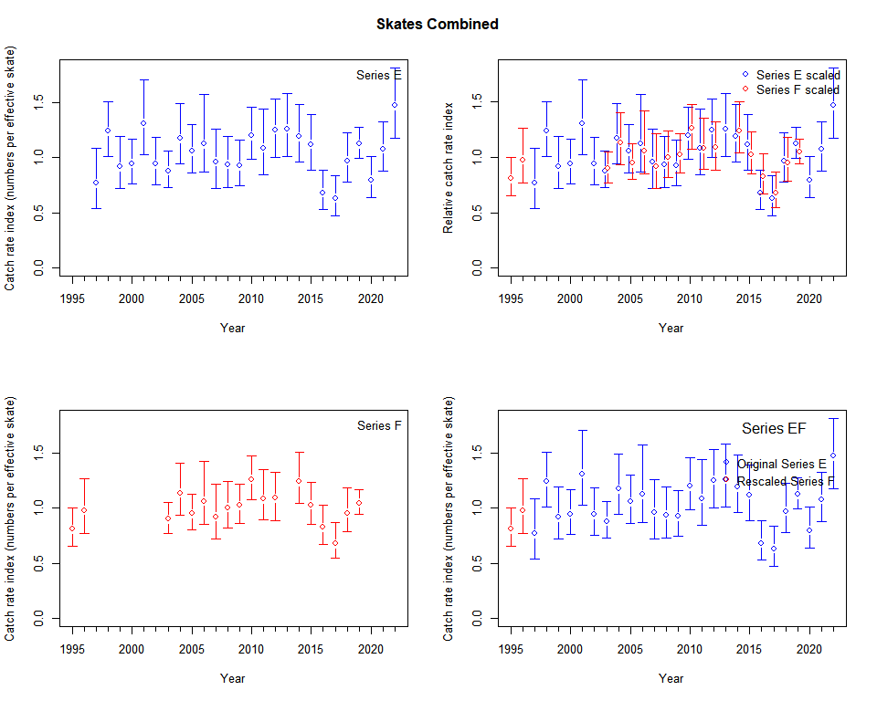

```r
assign(sp_hyphenate(sp, underscore = TRUE, area = TRUE),
       iphc_get_calc_plot_area(sp,
                               cached_data = cached_data,
                               cached_results = cached_results,
                               path_data = path_data,
                               path_results = path_results))
```

## Individual non-skate species

Similarly for the other species:

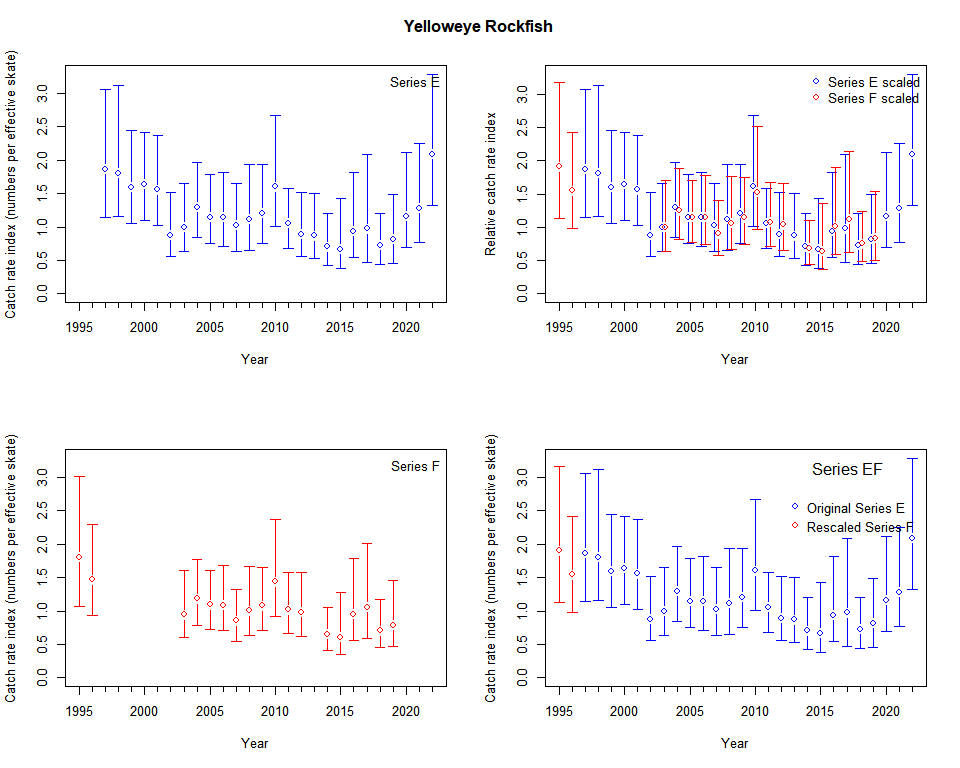

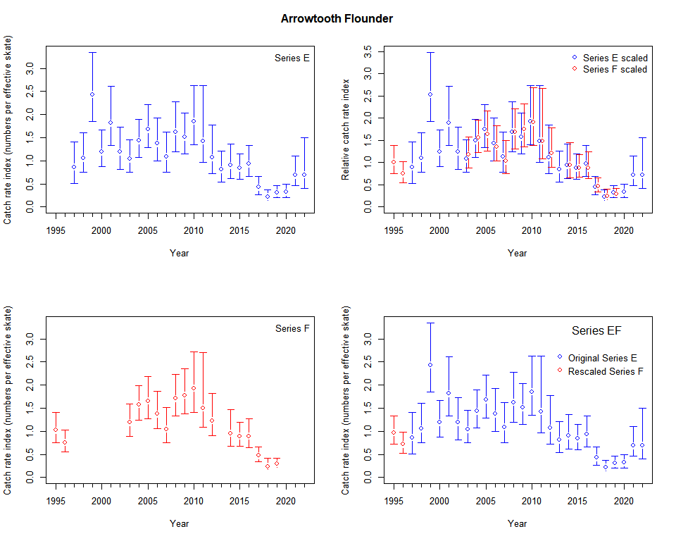

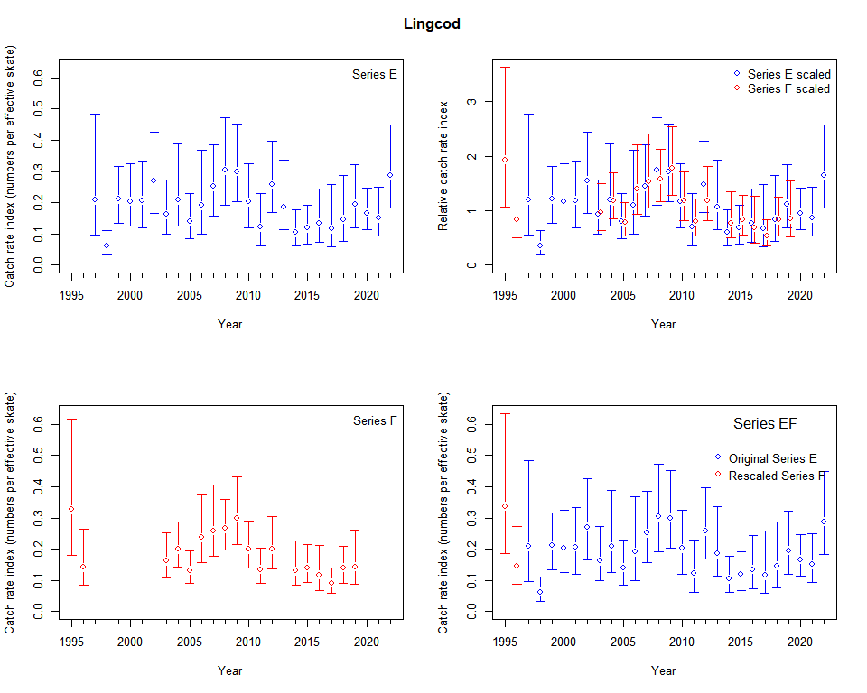

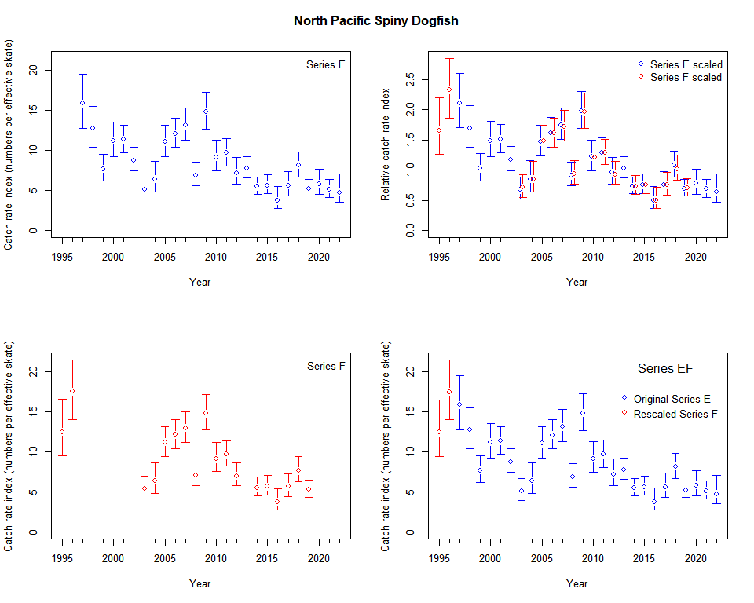

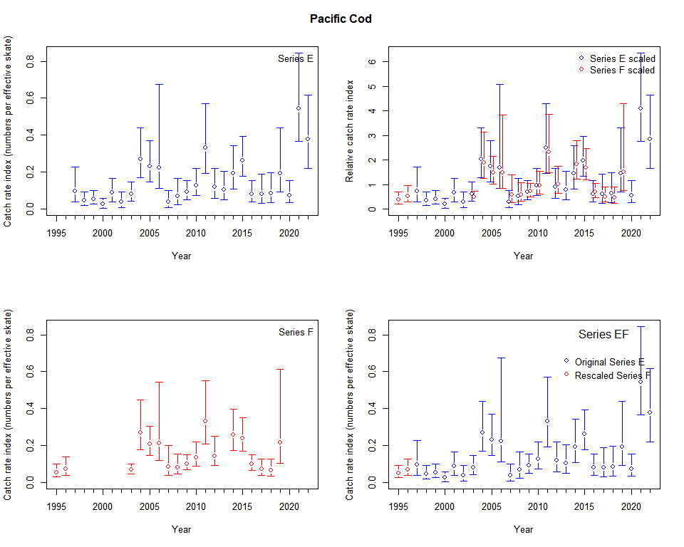

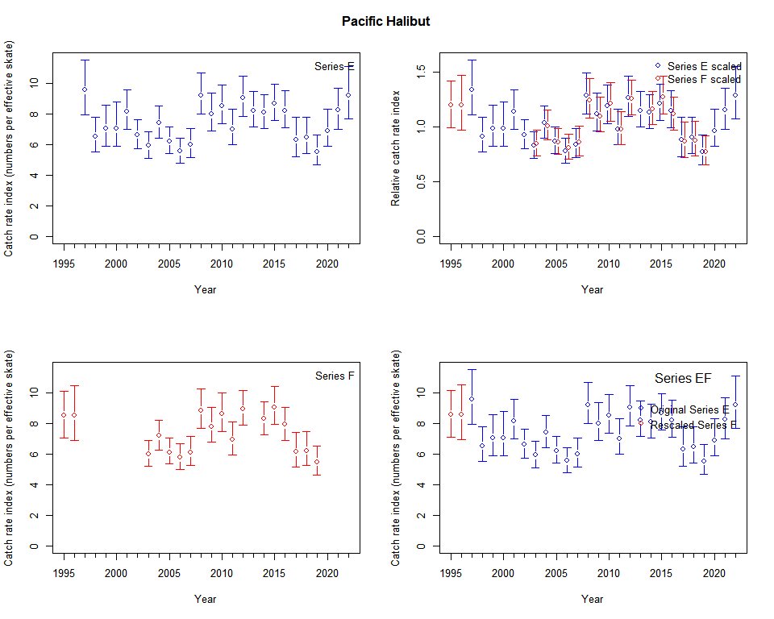

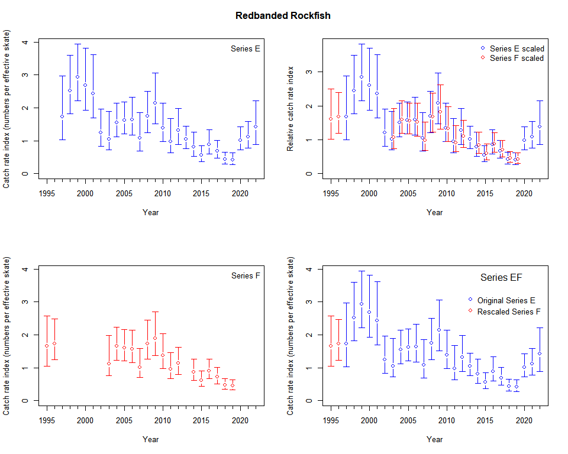

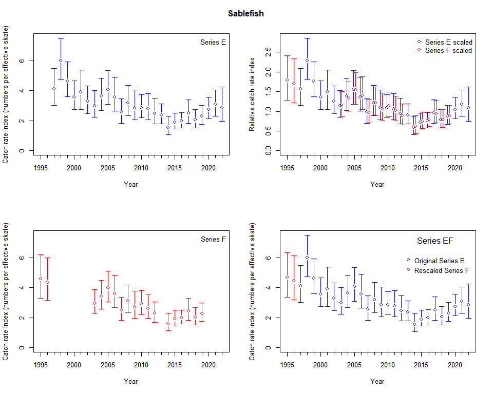

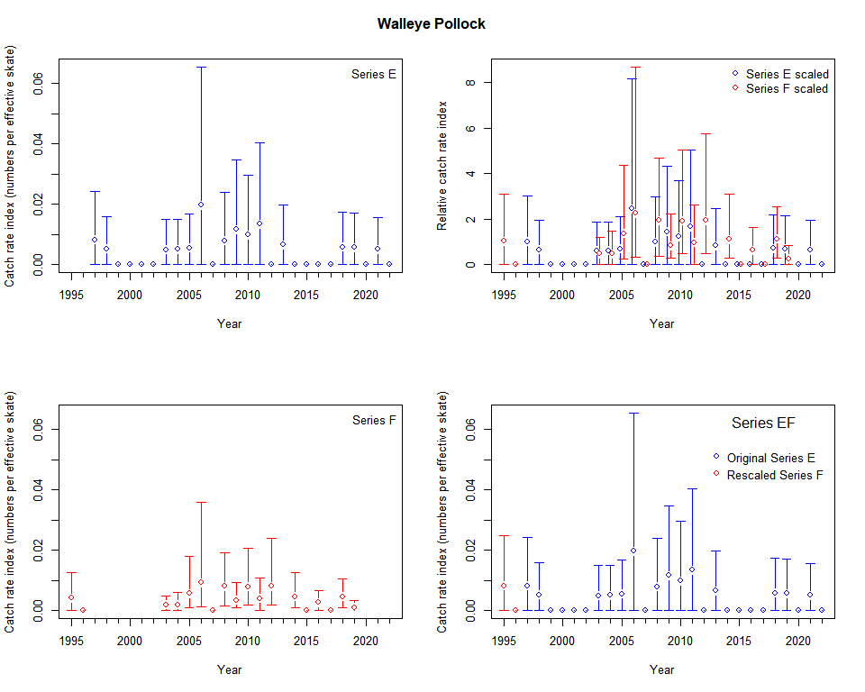

```r
for(sp in sp_vec){
  assign(sp_hyphenate(sp, underscore = TRUE, area = TRUE),
         iphc_get_calc_plot_area(sp,
                                 cached_data = cached_data,
                                 cached_results = cached_results,
                                 path_data = path_data,
                                 path_results = path_results))
}
```

## Format for Jennifer’s EAFM summary

Save annual indices (with uncertainty) for all species of interest, in the format for the HG herring predators’ EAFM summary (some 2020 versions are in `for-jen-earlier-versions/`, each later year will be saved along with everything else in `vignettes-results-20**-data/`.

```r
all_sp_longest <- list()
sp_vec_and_combined_skates <- c(sp_vec, "skates combined")
# Do this to easily create arguments for iphc_format_for_EAFM(); can't easily
#  functionalise. Each element is names for the species, and is a tibble of
#  longest time series.
for(sp in sp_vec_and_combined_skates){
  all_sp_longest[[sp]] <- get(paste0(sp_hyphenate(sp,
                                                  underscore = TRUE,
                                                  area = TRUE)))$series_longest$ser_longest
}

eafm_res <- iphc_format_for_EAFM(sp_vec_and_combined_skates,
                                 path = path_results,
                                 all_sp_longest) # also saves .csv, and .rds of
                                                 #  all_sp_longest list

eafm_res
```

```
#> # A tibble: 840 × 3
#>     Year Indicator                              Value
#>    <dbl> <chr>                                  <dbl>
#>  1  1995 YelloweyeRockfish_IPHC_SurveyCatchRate 1.90
#>  2  1995 YelloweyeRockfish_IPHC_LowerCI         1.13
#>  3  1995 YelloweyeRockfish_IPHC_UpperCI         3.17
#>  4  1996 YelloweyeRockfish_IPHC_SurveyCatchRate 1.54
#>  5  1996 YelloweyeRockfish_IPHC_LowerCI         0.984
#>  6  1996 YelloweyeRockfish_IPHC_UpperCI         2.42
#>  7  1997 YelloweyeRockfish_IPHC_SurveyCatchRate 1.86
#>  8  1997 YelloweyeRockfish_IPHC_LowerCI         1.14
#>  9  1997 YelloweyeRockfish_IPHC_UpperCI         3.05
#> 10  1998 YelloweyeRockfish_IPHC_SurveyCatchRate 1.81
#> # … with 830 more rows
```

Note that the analyses may not yet fully account for all possibilities (for all areas and species), particularly for rarer species. So do check that the output is sensible by inspecting the above time series figures. And the analyses do not (yet) include hook competition, which is currently being investigated.